# Chapter 2 World Trade: An Overview

# Preview

- Largest trading partners of the United States
- Gravity model:
  - influence of an economy’s size on trade
  - distance and other factors that influence trade
- Borders and trade agreements
- Globalization: then and now
- Changing composition of trade
- Service outsourcing

# Who Trades with Whom?

# Who Trades with Whom?

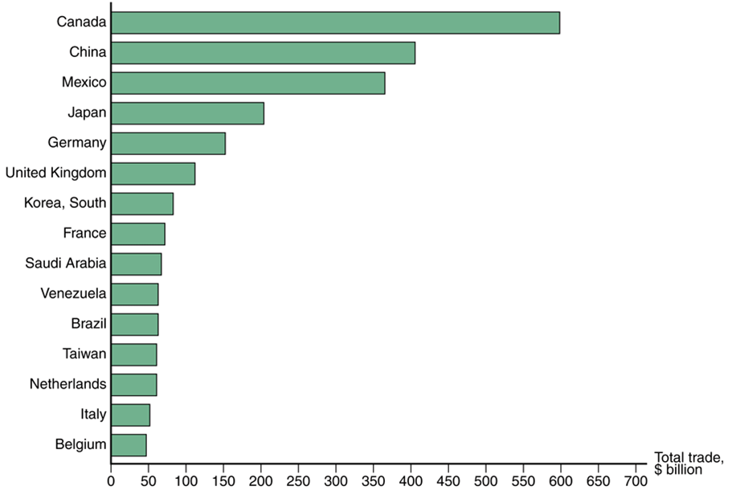

# Size Matters: The Gravity Model

- 3 of the top 10 trading partners with the U.S. in 2008 were also the 3 largest European economies: Germany, U.K., and France.
- These countries have the largest **gross domestic product (GDP)** in Europe.
  - GDP measures the value of goods and services produced in an economy.
- Why does the U.S. trade most with these European countries and not other European countries?

# Size Matters: The Gravity Model

- In fact, the size of an economy is directly related to the volume of imports and exports.
  - Larger economies produce more goods and services, so they have more to sell in the export market.
  - Larger economies generate more income from the goods and services sold, so they are able to buy more imports.

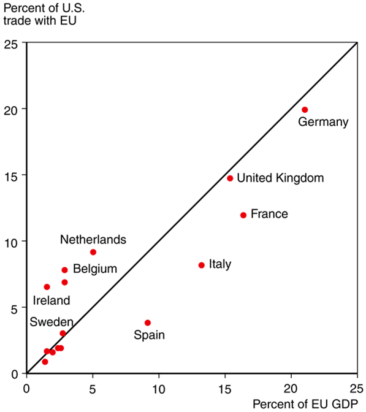

# The Gravity Model

- Other things besides size matter for trade:
  1. *Distance* between markets influences transportation costs and therefore the cost of imports and exports.
     - Distance may also influence personal contact and communication, which may influence trade.
  2. *Cultural affinity*: if two countries have cultural ties, it is likely that they also have strong economic ties.
  3. *Geography*: ocean harbors and a lack of mountain barriers make transportation and trade easier.

# The Gravity Model

4. Multinational corporations: corporations spread across different nations import and export many goods between their divisions.
5. Borders: crossing borders involves formalities that take time and perhaps monetary costs like tariffs.
   - These implicit and explicit costs reduce trade.
   - The existence of borders may also indicate the existence of different languages (see 2) or different currencies, either of which may impede trade more.

# The Gravity Model

- In its basic form, the gravity model assumes that only size and distance are important for trade in the following way: $T_{ij}=\frac{A\times Y_i\times Y_j}{D_{ij}}$
- where
  - $T_{ij}$ is the value of trade between country *i* and country *j*
  - $A$ is a constant
  - $Y_i$ the GDP of country *i*
  - $Y_j$ is the GDP of country *j*
  - $D_{ij}$ is the distance between country *i* and country *j*

# The Gravity Model

- In a slightly more general form, the gravity model that is commonly estimated is $T_{ij}=\frac{A\times Y_i^a\times Y_j^b}{D_{ij}^c}$ where *a*, *b*, and *c* are allowed to differ from 1.
- Despite its simplicity, the gravity model works fairly well in predicting actual trade flows, as the figure above representing U.S.–EU trade flows suggested.

# Distance and Borders

- Estimates of the effect of distance from the gravity model predict that a 1% increase in the distance between countries is associated with a decrease in the volume of trade of 0.7% to 1%.
- Besides distance, borders increase the cost and time needed to trade.
- *Trade agreements* between countries are intended to reduce the formalities and tariffs needed to cross borders, and therefore to increase trade.

# Distance and Borders

- The gravity model can assess the effect of trade agreements on trade: does a trade agreement lead to significantly more trade among its partners than one would otherwise predict given their GDPs and distances from one another?
- The U.S. signed a free trade agreement with Mexico and Canada in 1994, the North American Free Trade Agreement (NAFTA).
- Because of NAFTA and because Mexico and Canada are close to the U.S., the amount of trade between the U.S. and its northern and southern neighbors as a fraction of GDP is larger than between the U.S. and European countries.

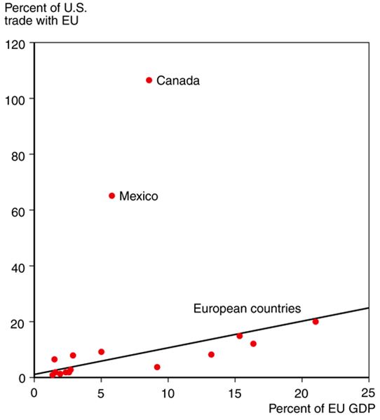

# Distance and Borders

- Yet even with a free trade agreement between the U.S. and Canada, which use a common language, the border between these countries still seems to be associated with a reduction in trade.

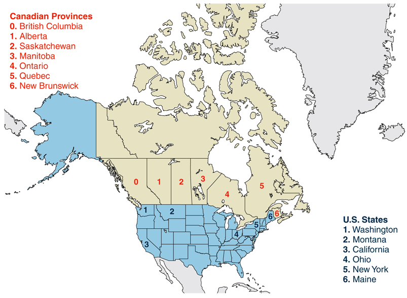

# Trade with British Columbia, as Percent of GDP, 1996

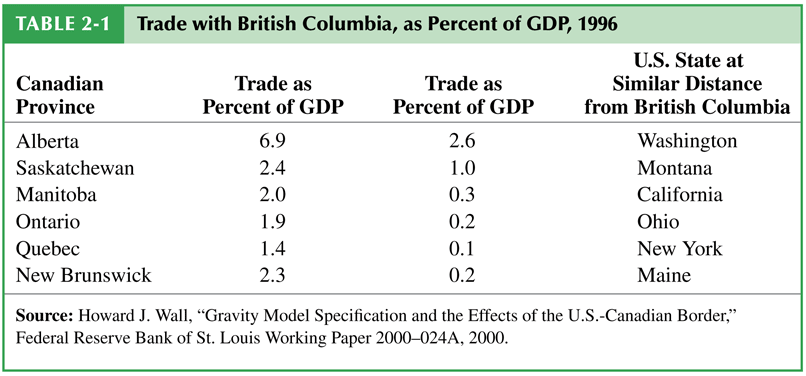

# The Changing Pattern of World Trade

# Has the World Become “Smaller”?

- The negative effect of distance on trade according to the gravity models is significant, but has grown smaller over time due to modern transportation and communication.
- Technologies that have increased trade:
  - Wheels, sails, compasses, railroads, telegraph, steam power, automobiles, telephones, airplanes, computers, fax machines, Internet, fiber optics, personal digital assistants, GPS satellites…

# Has the World Become “Smaller”?

- Political factors, such as wars, can change trade patterns much more than innovations in transportation and communication.
- World trade grew rapidly from 1870 to 1913.
  - Then it suffered a sharp decline due to the two world wars and the Great Depression.
  - It started to recover around 1945 but did not recover fully until around 1970.
- Since 1970, world trade as a fraction of world GDP has achieved unprecedented heights.

# World Exports as a Percentage of World GDP

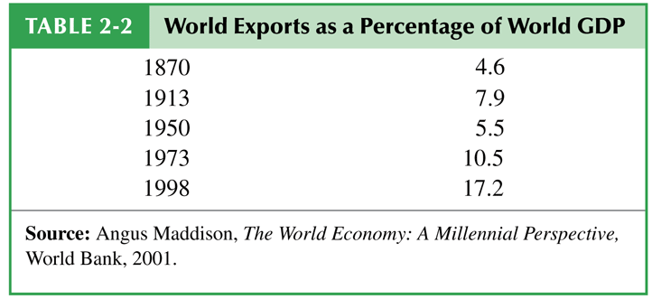

# Changing Composition of Trade

- What kinds of products do nations trade now, and how does this composition compare to trade in the past?
- Today, most (about 55%) of the volume of trade is in manufactured products such as automobiles, computers, clothing and machinery.
  - Services such as shipping, insurance, legal fees, and spending by tourists account for about 20% of the volume of trade.
  - Mineral products (ex., petroleum, coal, copper) and agricultural products are a relatively small part of trade.

# World Trade, 2008

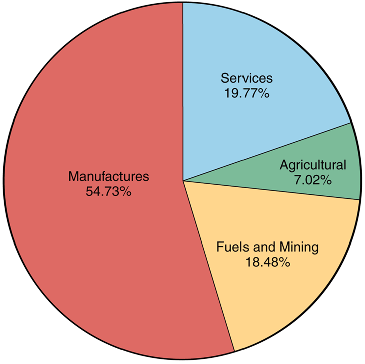

# Changing Composition of Trade

# Manufactured Goods as a Percent of Merchandise Trade

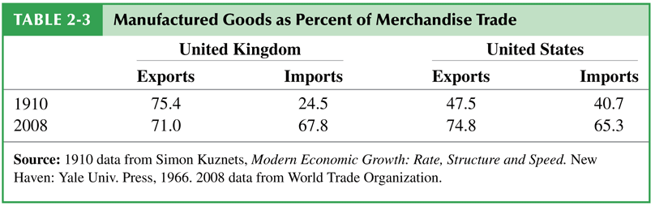

# Changing Composition of Trade

- Low- and middle-income countries have also changed the composition of their trade.
  - In 2001, about 65% of exports from low- and middle-income countries were manufactured products, and only 10% of exports were agricultural products.
  - In 1960, about 58% of exports from low- and middle-income countries were agricultural products and only 12% of exports were manufactured products.

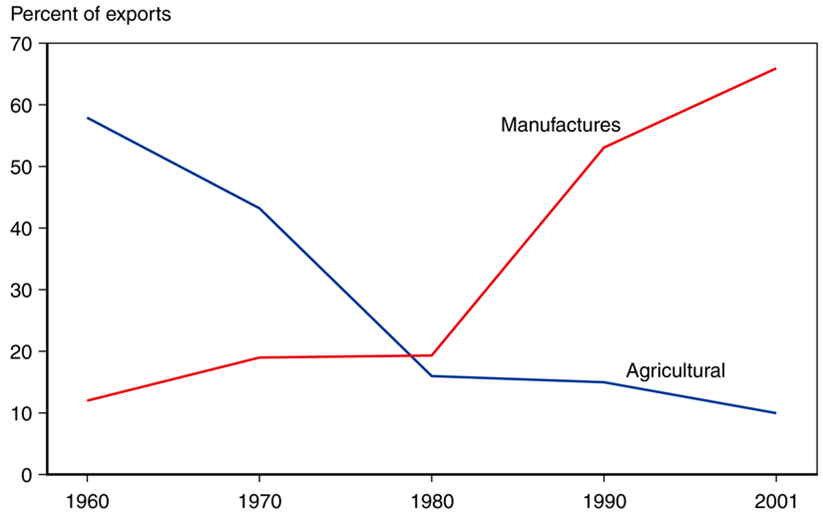

# Service Outsourcing

- **Service outsourcing (or offshoring)** occurs when a firm that provides services moves its operations to a foreign location.
  - Service outsourcing can occur for services that can be performed and transmitted electronically.
    - For example, a firm may move its customer service centers whose telephone calls can be transmitted electronically to a foreign location.

# Service Outsourcing

- Service outsourcing is currently not a significant part of trade.
  - Some jobs are “tradable” and thus have the potential to be outsourced.
  - Most jobs are nontradable because they need to be done close to the customer.

# Share of Employment

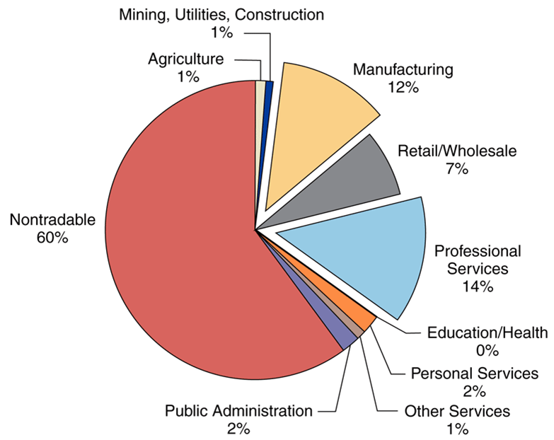

# Summary

# Summary

1. The 5 largest trading partners with the U.S. are Canada, China, Mexico, Japan, and Germany.
2. The largest economies in the EU undertake the largest fraction of the total trade between the EU and the U.S.
3. The gravity model predicts that the volume of trade is directly related to the GDP of each trading partner and is inversely related to the distance between them.

# Summary

4. Besides size and distance, culture, geography, multinational corporations, and the existence of borders influence trade.
5. Modern transportation and communication have increased trade, but political factors have influenced trade more in history.
6. Today, most trade is in manufactured goods, while historically agricultural and mineral products made up most of trade.